# homework5_kw3041

2025-11-11

```r
library(tidyverse)
library(broom)
```

## Problem 1.

# Function to test if there are duplicate birthdays in a group

```r
birthday_duplicate = function(n_people) {
  birthdays = sample(1:365, n_people, replace = TRUE)
  return(length(unique(birthdays)) < n_people)
}
```

```r
set.seed(123)
n_sim = 10000
group_sizes = 2:50

results = tibble(
  group_size = group_sizes,
  prob_shared_birthday = map_dbl(group_sizes, function(n) {
    mean(replicate(n_sim, birthday_duplicate(n)))
  })
)
```

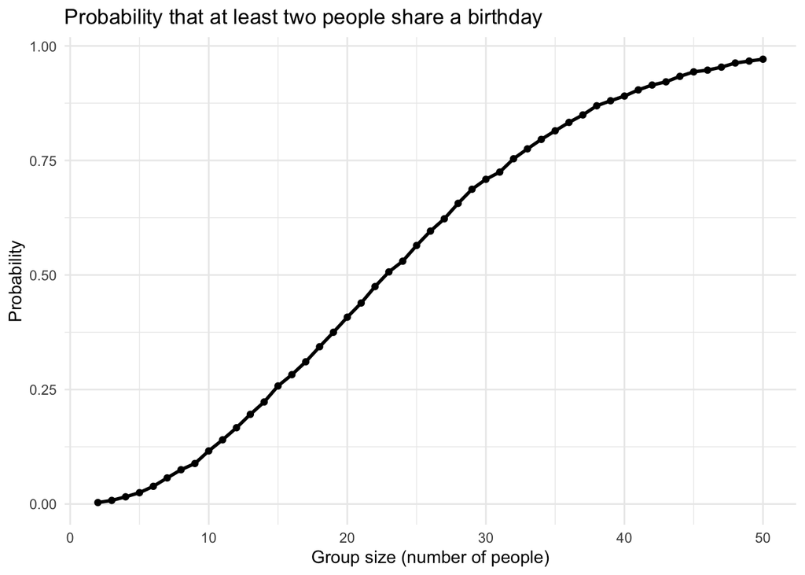

```r
results %>%
  ggplot(aes(x = group_size, y = prob_shared_birthday)) +
  geom_line(size = 1) +
  geom_point() +
  labs(
    title = "Probability that at least two people share a birthday",
    x = "Group size (number of people)",
    y = "Probability"
  ) +
  theme_minimal()
```

```r
print(results)
```

```
## # A tibble: 49 × 2
##    group_size prob_shared_birthday
##         <int>                <dbl>
##  1          2               0.0033
##  2          3               0.0079
##  3          4               0.0158
##  4          5               0.0248
##  5          6               0.0387
##  6          7               0.057
##  7          8               0.0749
##  8          9               0.0885
##  9         10               0.116
## 10         11               0.140
## # ℹ 39 more rows
```

Interpretation: The plot shows the classic birthday paradox: even for relatively small group sizes, the probability that at least two people share a birthday increases rapidly.

At n ≈ 23, the probability is already around 50%.

Despite intuition suggesting collisions should be rare, the number of possible pairs grows quadratically with group size, which makes duplicates increasingly likely even when birthdays are uniformly distributed.

## Problem 2

```r
n = 30
sigma = 5
mu_values = 0:6
n_sim = 5000
```

```r
set.seed(123)

results = expand_grid(mu = mu_values, sim = 1:n_sim) |>
  mutate(
    x = map(mu, ~ rnorm(n, mean = .x, sd = sigma)),
    test = map(x, ~ t.test(.x, mu = 0)),
    tidy = map(test, broom::tidy)
  ) |>
  unnest(tidy) |>
  select(mu, estimate, p.value)
```

```r
power_summary = results |>
  group_by(mu) |>
  summarise(power = mean(p.value < 0.05))
```

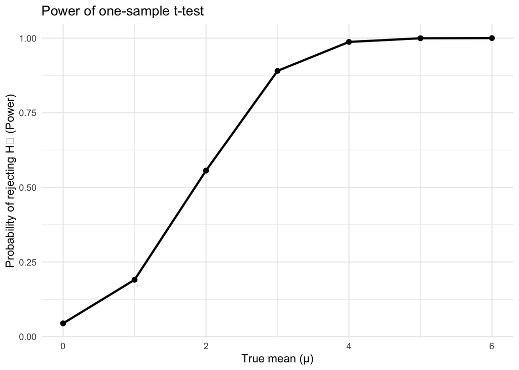

```r
power_summary |>
  ggplot(aes(x = mu, y = power)) +
  geom_line(size = 1) +
  geom_point(size = 2) +
  labs(
    title = "Power of one-sample t-test",
    x = "True mean (μ)",
    y = "Probability of rejecting H₀ (Power)"
  ) +
  theme_minimal()
```

Averagning stimtaes:

```r
estimates_summary = results |>
  group_by(mu) |>
  summarise(
    mean_est_all = mean(estimate),
    mean_est_reject = mean(estimate[p.value < 0.05])
  )
```

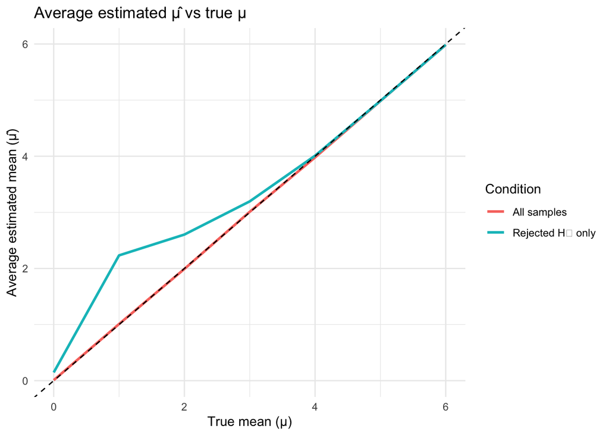

```r
estimates_summary |>
  ggplot(aes(x = mu)) +
  geom_line(aes(y = mean_est_all, color = "All samples"), size = 1) +
  geom_line(aes(y = mean_est_reject, color = "Rejected H₀ only"), size = 1) +
  geom_abline(intercept = 0, slope = 1, linetype = "dashed") +
  labs(
    title = "Average estimated μ̂ vs true μ",
    x = "True mean (μ)",
    y = "Average estimated mean (μ̂)",
    color = "Condition"
  ) +
  theme_minimal()
```

Power vs Effect Size: As the true mean μ increases, the probability of rejecting the null hypothesis (power) also increases. When μ = 0, power ≈ 0.05, as expected under a true null (Type I error rate).

Larger effect sizes (μ ≥ 3) show power approaching 1. This relationship occurs because stronger true effects shift the sampling distribution further away from 0, making it more likely that the t-test detects the difference.

Bias in Estimates When Conditioning on Rejection: The first line in the plot (all samples) shows that mean(μ̂) is approximately equal to the true μ for each effect size, as expected, since the estimator is unbiased. However, the second line (estimate only for samples where H₀ was rejected) lies above the 1:1 line, especially for small effect sizes.

What it means is that: When the true effect is small (e.g., μ = 1 or 2), the only datasets that produce significant results tend to be those where random noise pushes the estimate upward. Conditioning on significance produces inflated effect size estimates — a phenomenon known as the winner’s curse or Type M error (magnitude error).

For large μ, this bias disappears because nearly all samples reject H₀.

## Problem 3

```r
homicide_data <- read_csv("https://raw.githubusercontent.com/washingtonpost/data-homicides/master/homicide-data.csv")
```